# A brief analysis of the U.S. prison population

Simon Xiong

2022-11-22

## Introduction

This dataset[Incarceration Trends Dataset]https://github.com/vera-institute/incarceration-trends presents a table of the number of different races, genders, and other categories in U.S. prisons. The breakdown according to different counties in different states helps us to effectively study whether there are social problems in U.S. prisons.

The direct stakeholders affected by this dataset are current inmates, suspects awaiting trial, and members of the legal department. Indirect stakeholders are all U.S. citizens. In my opinion, although prison racism has begun to improve in recent years, there is still a strong level of prison racism in many states.

## Data Summary

I found very interesting data based on the last 2018 in the dataset as a standard, based on the total number of blacks in prison as a percentage of all people. According to the calculations, in 2018, DC (Washington D.C.) had the highest percentage of blacks in prison of all states, as much as 85.9912748%. ID (Idaho) had the lowest percentage of people, with only 3.1769417%. The average percentage of each state is 28.7670075%. Reflecting the fact that each state is not very equal in terms of ethnicity.

## Growth of the U.S. Prison Population

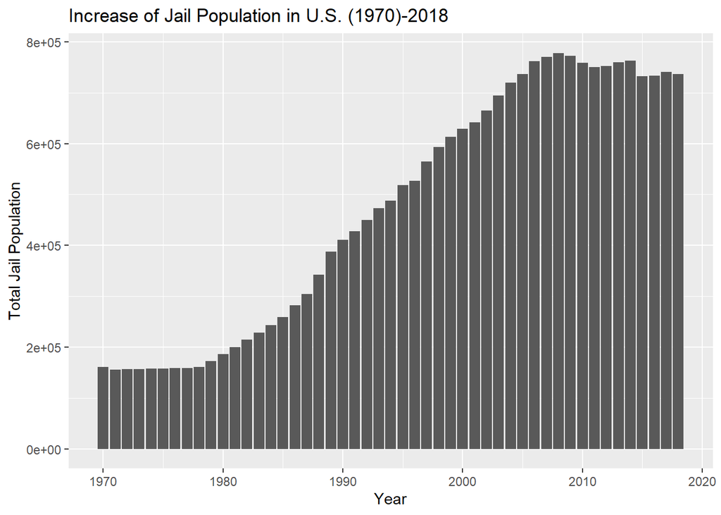

This chart shows a histogram of the number of people in prison in total from 1970 to 2018, and we can see that there was a period of rapid increase between 1980 and 2010, and a much flatter period at both ends.

## Growth of Prison Population by State

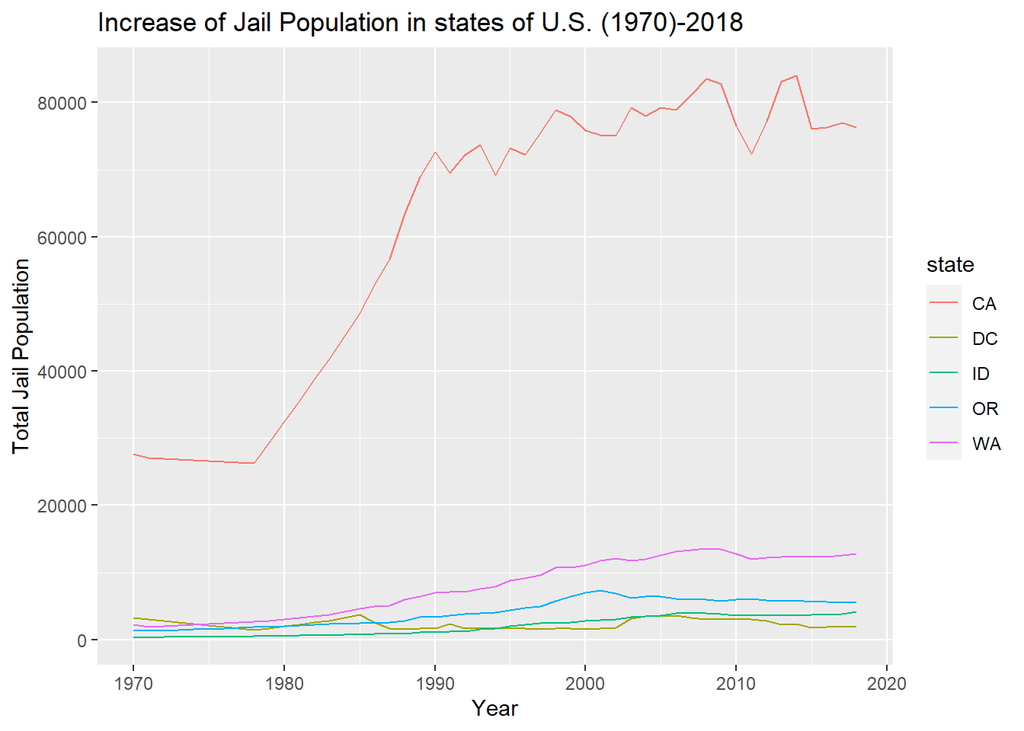

This chart shows the change in prison population in each state from 1970 to 2018, with CA remaining high and trending upward, and the remaining states rising slightly, but still relatively stable.

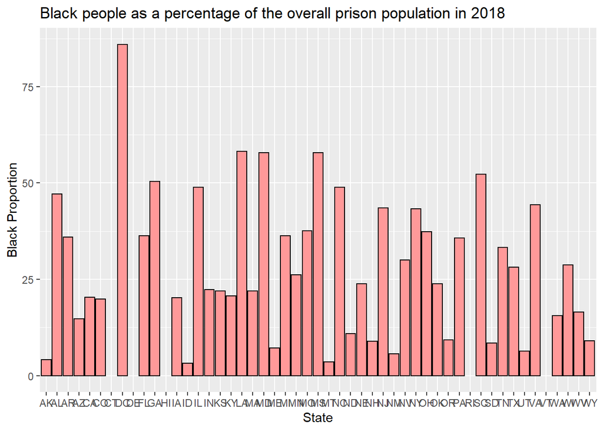

*Is there a serious prison racial problem situation in each state? Which states have the most severe?*

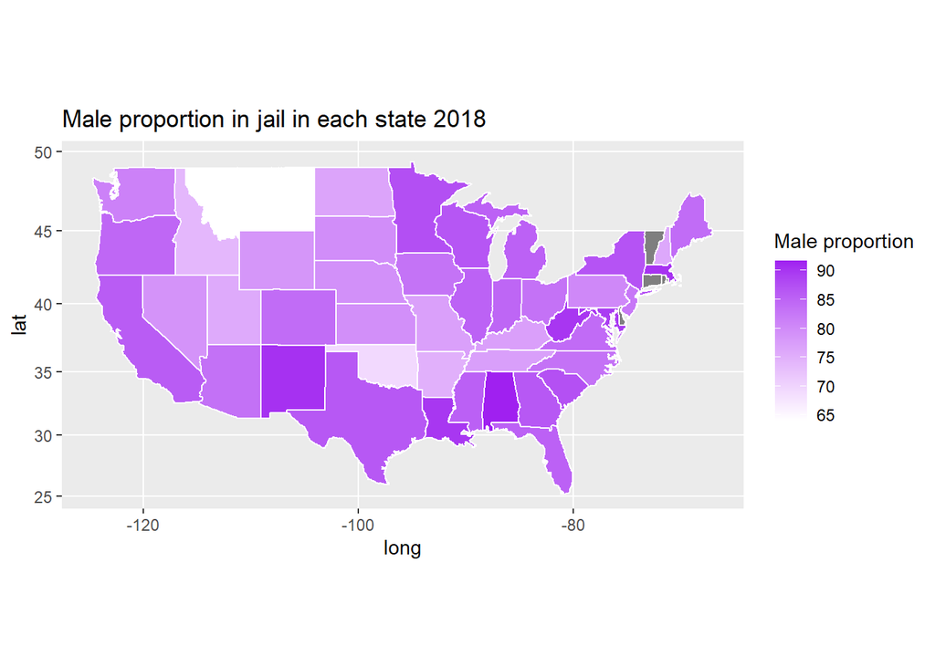

*Is there gender discrimination in prisons within each state?*